# Predicting Diabetes

Demi van den Biggelaar (9660089)

August Gesthuizen (5292565)

Friso Harff (7526946)

Leander van der Waal (7180063)

2026-01-15

## Inhoudsopgave

- Research Question
- The Data
- Models
- The Best Model
- Assumptions
- Conclusion model
- Answer Research Question

## Introduction Research Question

- Diabetes
- Common
- Diagnosis

## The Research Question

Can we predict if someone is diabetic using research data with a logistic regression using Age, Glucose, BMI en DiabetesPedigreeFunction?

## The Dataset

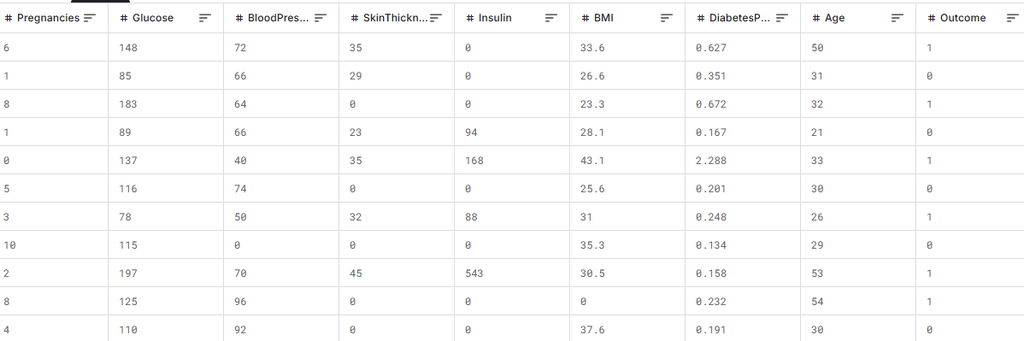

National Institute of Diabetes and Digestive and Kidney Diseases (1990)

## Exploring the data

- Pregnancies: Number of times pregnant
- Glucose: Plasma glucose concentration a 2 hours in an oral glucose tolerance test
- BloodPressure: Diastolic blood pressure (mm Hg)
- SkinThickness: Triceps skin fold thickness (mm)
- Insulin: 2-Hour serum insulin (mu U/ml)
- BMI: Body mass index (weight in kg/(height in m)^2)
- DiabetesPedigreeFunction: a function that scores the probability of diabetes based on family history, with a realistic range of 0.08 to 2.42
- Age: Age (years)
- Outcome: Class variable (0 or 1)

## Preprocessing

```r
# Recoding BMI to classes
dataRDS$BMI[dataRDS$BMI <= 18.5 ] <- 1                     # Underweight
dataRDS$BMI[dataRDS$BMI > 18.5 & dataRDS$BMI <= 25  ] <- 2 # Healthy
dataRDS$BMI[dataRDS$BMI > 25 & dataRDS$BMI <= 30 ] <- 3    # Overweight
dataRDS$BMI[dataRDS$BMI > 30] <- 4                         # Obese

# Removing missing values
dataRDS <- subset(dataRDS,
                     BloodPressure != 0 &
                     SkinThickness != 0 &
                     Glucose != 0 &
                     Insulin != 0 &
                     BMI != 0)
```

## Interesting Finds

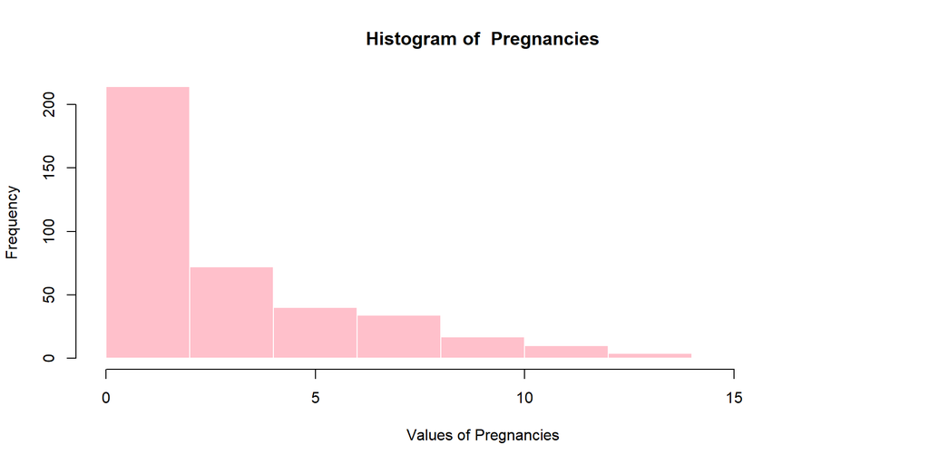

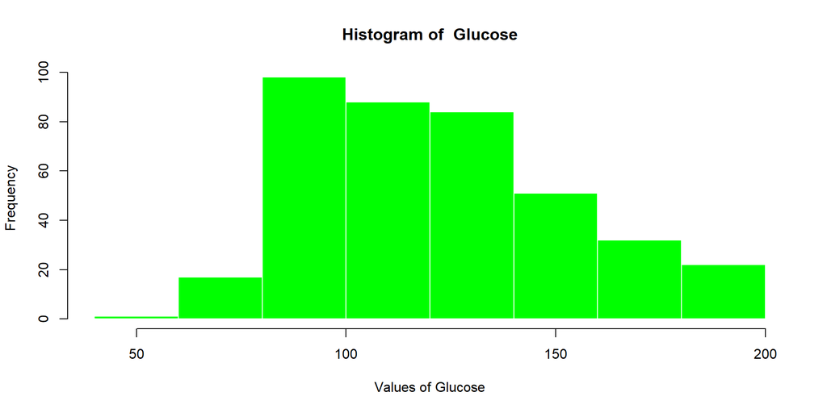

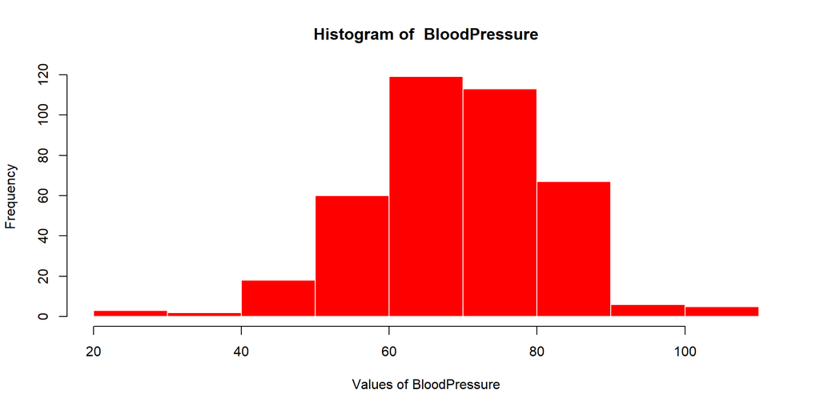

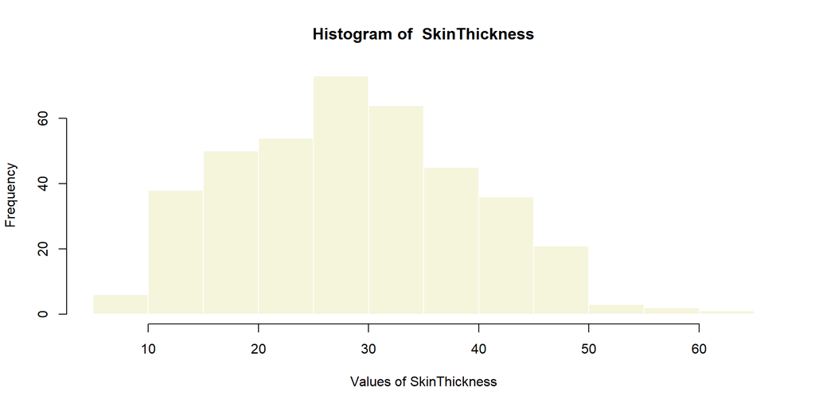

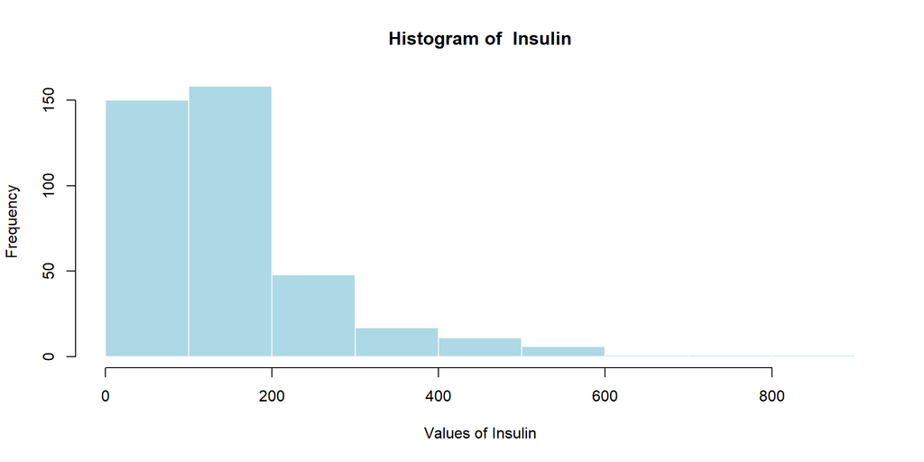

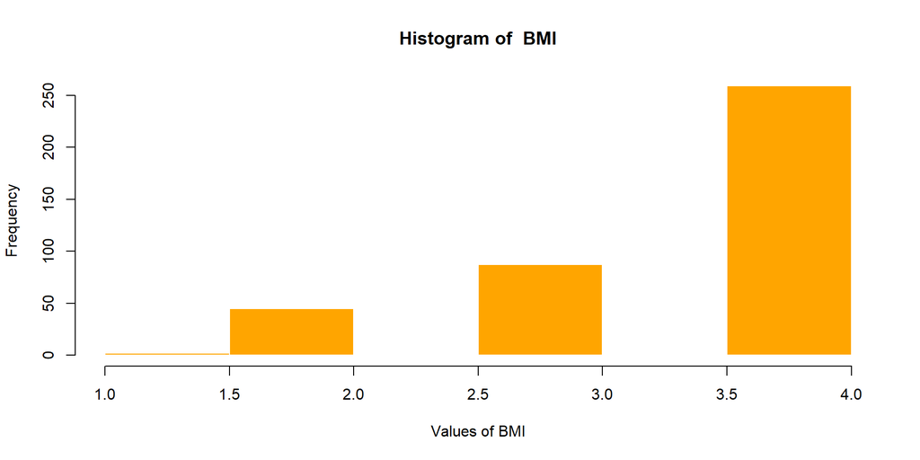

259/393 = 66% are obese

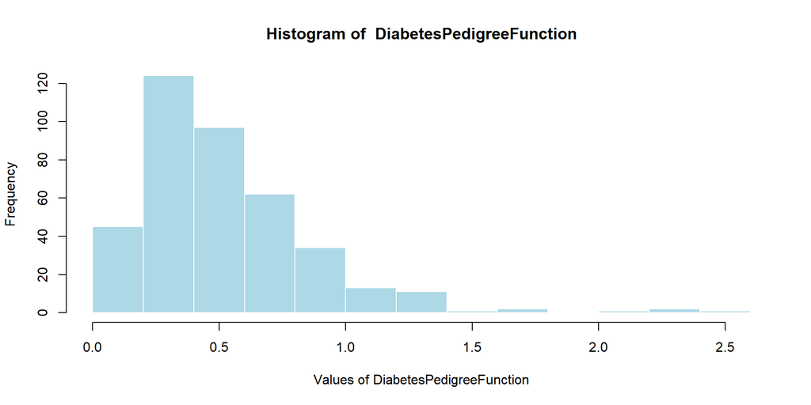

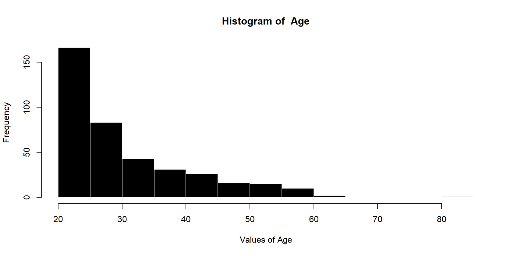

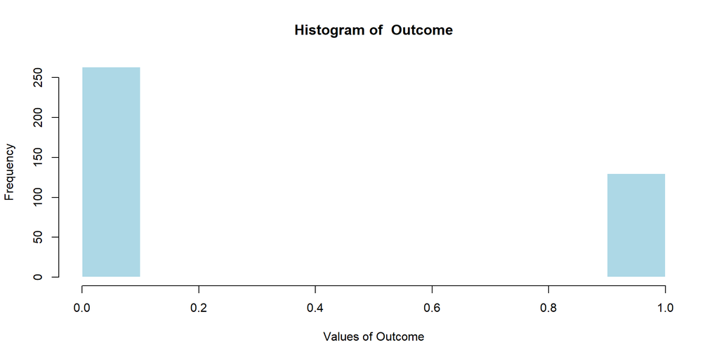

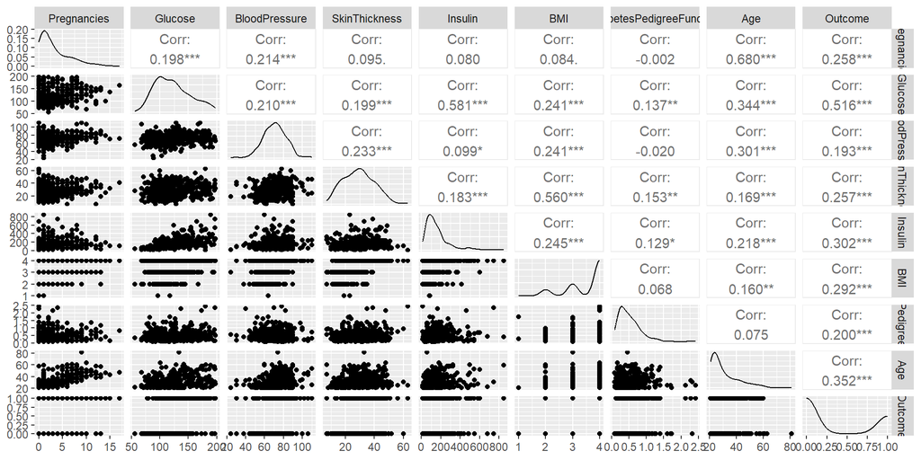

## Model comparison

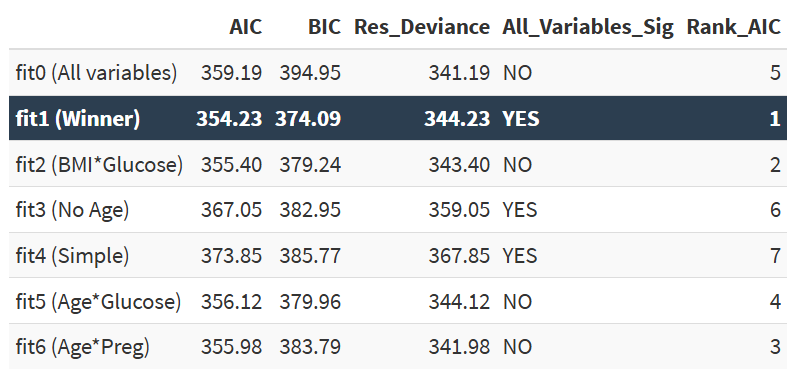

## Model summary’s - Fit 6

```
Call:
glm(formula = Outcome ~ Glucose + BMI + DiabetesPedigreeFunction +
    Age * Pregnancies, family = binomial, data = dataRDS)

Coefficients:
                           Estimate Std. Error z value Pr(>|z|)
(Intercept)              -11.338734   1.384261  -8.191 2.59e-16 ***
Glucose                    0.035578   0.005019   7.088 1.36e-12 ***
BMI                        0.989748   0.261120   3.790  0.00015 ***
DiabetesPedigreeFunction   1.182371   0.416548   2.838  0.00453 **
Age                        0.050940   0.027112   1.879  0.06027 .
Pregnancies                0.197751   0.170070   1.163  0.24492
Age:Pregnancies           -0.003446   0.004322  -0.797  0.42525
---
Signif. codes:  0 '***' 0.001 '**' 0.01 '*' 0.05 '.' 0.1 ' ' 1

(Dispersion parameter for binomial family taken to be 1)

    Null deviance: 498.90  on 392  degrees of freedom
Residual deviance: 341.98  on 386  degrees of freedom
AIC: 355.98

Number of Fisher Scoring iterations: 5
```

## Fit 2

```
Call:
glm(formula = Outcome ~ Age + Glucose + BMI + DiabetesPedigreeFunction +
    Glucose * BMI, family = binomial, data = dataRDS)

Coefficients:
                          Estimate Std. Error z value Pr(>|z|)
(Intercept)              -16.05571    5.85345  -2.743 0.006089 **
Age                        0.04952    0.01347   3.676 0.000237 ***
Glucose                    0.07421    0.04408   1.684 0.092266 .
BMI                        2.30316    1.51490   1.520 0.128426
DiabetesPedigreeFunction   1.16460    0.41642   2.797 0.005163 **
Glucose:BMI               -0.01013    0.01144  -0.885 0.376090
---
Signif. codes:  0 '***' 0.001 '**' 0.01 '*' 0.05 '.' 0.1 ' ' 1

(Dispersion parameter for binomial family taken to be 1)

    Null deviance: 498.9  on 392  degrees of freedom
Residual deviance: 343.4  on 387  degrees of freedom
AIC: 355.4

Number of Fisher Scoring iterations: 6
```

## Fit 1

```
Call:
glm(formula = Outcome ~ Age + Glucose + BMI + DiabetesPedigreeFunction,
    family = binomial, data = dataRDS)

Coefficients:
                           Estimate Std. Error z value Pr(>|z|)
(Intercept)              -11.102813   1.279984  -8.674  < 2e-16 ***
Age                        0.050595   0.013463   3.758 0.000171 ***
Glucose                    0.035632   0.005019   7.099 1.26e-12 ***
BMI                        0.998930   0.258862   3.859 0.000114 ***
DiabetesPedigreeFunction   1.129221   0.413553   2.731 0.006323 **
---
Signif. codes:  0 '***' 0.001 '**' 0.01 '*' 0.05 '.' 0.1 ' ' 1

(Dispersion parameter for binomial family taken to be 1)

    Null deviance: 498.90  on 392  degrees of freedom
Residual deviance: 344.23  on 388  degrees of freedom
AIC: 354.23

Number of Fisher Scoring iterations: 5
```

## Best model fit

```r
fit1 <- glm(Outcome ~ Age + Glucose + BMI + DiabetesPedigreeFunction,
            family = binomial,
            data = dataRDS)
```

- comparison with ggpairsplot
- Interpretation

## Binary dependent variable

- Diabetes (coded 1)
- Not diabetes (coded 0)

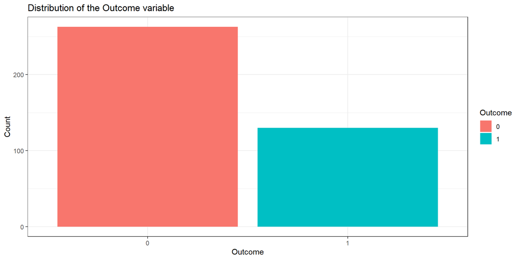

## Sufficiently large sample size

- 10 cases per candidate predictor : $N=\frac{10k}{p}$

```
  Outcome   n      prop
1       0 263 0.6692112
2       1 130 0.3307888
```

- k=4, p=0.33 -> 121 required
- 130 positive

## Full-rank predictor matrix

- More observations than predictors
- No multicollinearity among linear predictors

```
                     Age                  Glucose                      BMI
                1.022157                 1.018869                 1.009314
DiabetesPedigreeFunction
                1.006276
```

- VIF=1 : no correlation

## Continuous predictors are linearly related to the $logit(\pi)$

- Continuous predictors : `Age`, Glucose and DiabetesPedigreeFunction

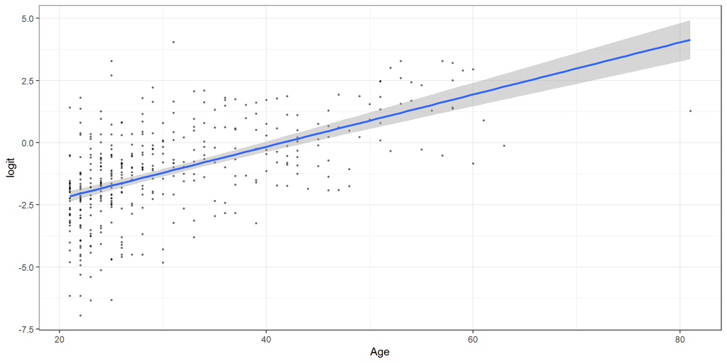

## Continuous predictors are linearly related to the $logit(\pi)$

- Continuous predictors : Age, `Glucose` and DiabetesPedigreeFunction

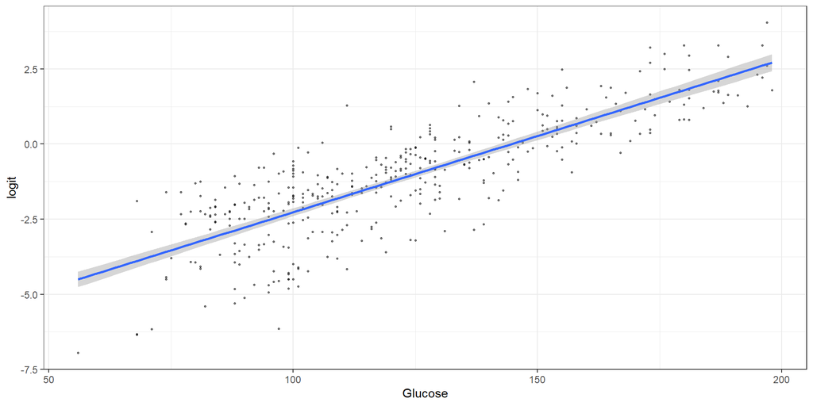

## Continuous predictors are linearly related to the $logit(\pi)$

- Continuous predictors : Age, Glucose and `DiabetesPedigreeFunction`

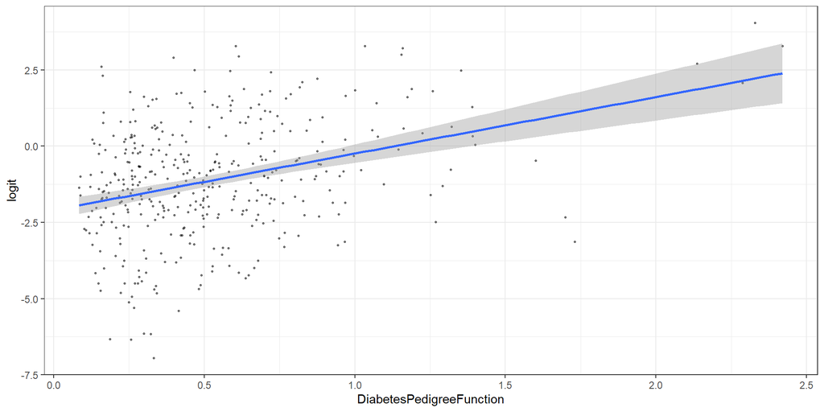

## No influential values or outliers

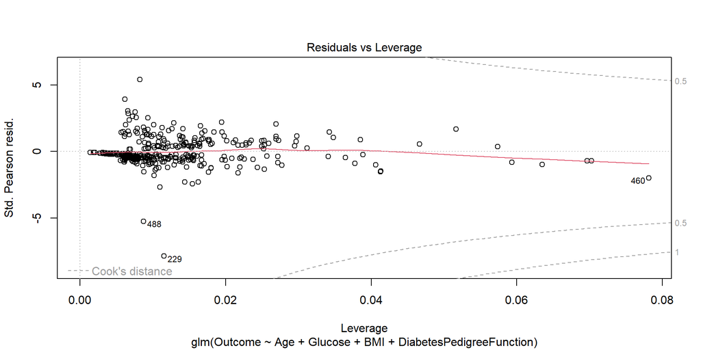

- No values outside Cook’s distance
- Maybe influential observations?

## Most influential observations

```
    Glucose Age BMI DiabetesPedigreeFunction
229     197  31   4                    2.329
460     134  81   3                    0.460
488     173  58   4                    1.159
```

## Removing most influential observations

```
   Model Null_Deviance Residual_Deviance    AIC
1   fit1       498.902           344.225 354.23
2 fit1.2       496.481           323.971 333.97
```

## Updated model

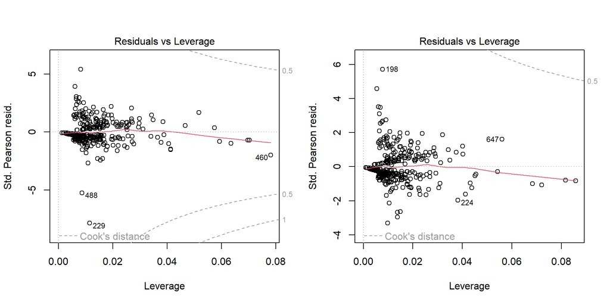

## Coefficients

```
                             Estimate  Std. Error   z value     Pr(>|z|)
(Intercept)              -11.10281260 1.279983660 -8.674183 4.165298e-18
Age                        0.05059467 0.013462839  3.758098 1.712097e-04
Glucose                    0.03563232 0.005019401  7.098919 1.257362e-12
BMI                        0.99893046 0.258861962  3.858931 1.138841e-04
DiabetesPedigreeFunction   1.12922062 0.413552881  2.730535 6.323161e-03
```

- The expected log-odds of diabetes for a zero-year-old with no glucose levels, BMI, or DiabetesPedigreeFunction are -11.103.
- An individual’s age significantly predicts their probability of diabetes, after controlling for glucose, BMI, and DiabetesPedigreeFunction (𝛽 = .051, z = 3.758, p < .000).
  - For each additional year of age, the expected log-odds of having diabetes increases with .051 units.
- An individual’s glucose levels significantly predicts their probability of diabetes, after controlling for age, BMI, and DiabetesPedigreeFunction (𝛽 = .036, z = 7.099, p < 1.26e-12).
  - For each additional level of glucose, the expected log-odds of having diabetes increases with .036 units.
- An individual’s BMI significantly predicts their probability of diabetes, after controlling for age, glucose, and DiabetesPedigreeFunction (𝛽 = .999, z = 3.859, p < .000).
  - For each additional level of BMI, the expected log-odds of having diabetes increases with .999 units.
- An individual’s DiabetesPedigreeFunction significantly predicts their probability of diabetes, after controlling for age, glucose, and BMI (𝛽 = 1.129, z = 2.731, p < .006).
  - For each additional DiabetesPedigreeFunction, the expected log-odds of having diabetes increases with 1.129 units.

## Odds ratios

```
             (Intercept)                      Age                  Glucose
            1.506988e-05             1.051896e+00             1.036275e+00
                     BMI DiabetesPedigreeFunction
            2.715376e+00             3.093245e+00
```

- The expected odds ratio for age are 1.052, or a 5,2% increase in the odds of having diabetes for every increasing value of age.
- The expected odds ratio for glucose are 1.036 or a 3.6% increase in the odds of having diabetes for every increasing value of glucose.
- The expected odds ratio for BMI are 2.715 or a 171,5% increase in the odds of having diabetes for every increasing value of BMI.
- The expected odds ratio for DiabetesPedigreeFunction are 3.093 or a 209.3% increase in the odds of having diabetes for every increasing value of diabetes pedigree function.

## Confusion Matrix

```
          Reference
Prediction   0   1
         0 234  54
         1  29  76
```

- A total of 393 individuals
  - 263 negative; no diabetes
  - 130 positive; diabetes
  - 234 of those 263 were correctly estimated to not have diabetes

Accuracy

```
[1] 78.88041
```

Specificity

```
[1] 88.97338
```

Sensitivity

```
[1] 58.46154
```

Positive Predictive Value

```
[1] 72.38095
```

False Positive Rate

```
[1] 11.02662
```

Negative predictive value

```
[1] 81.25
```

## ROC

```
Area under the curve: 0.8618
```

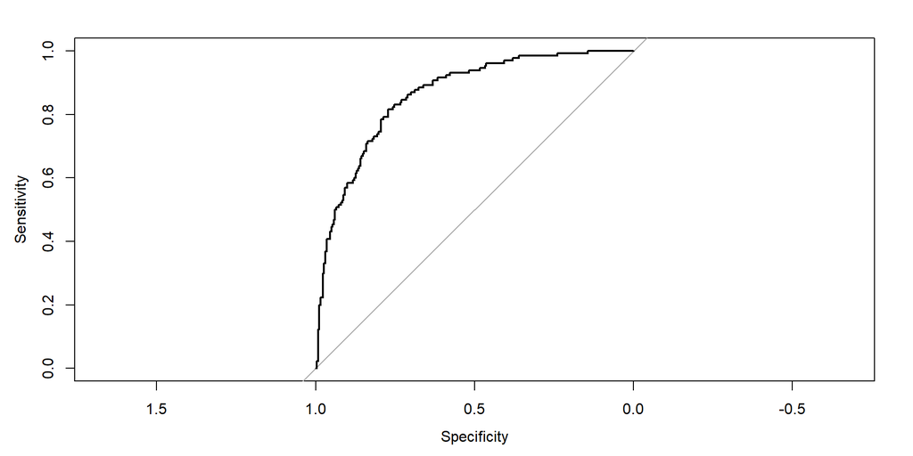